# GLMM Distributions: Counts, Incidence, Proportions, and Zero Inflation

mixedFlowR tutorial series

# 1 Purpose

This vignette extends the mixed-model framework to non-Gaussian responses. The focus is not on memorizing distributions. The objective is to connect the measurement process to an appropriate conditional distribution, link function, random structure, and diagnostic workflow.

`mixedFlowR` uses `lme4` and `glmmTMB` as principal GLMM engines, with `glmmTMB` providing especially broad support for negative-binomial, beta, zero-inflated, and dispersion models (Brooks et al. 2017).

# 2 1. Learning objectives

You will learn to:

- distinguish binary/binomial, count, and continuous-proportion outcomes;
- understand the role of the link function;
- fit binomial, Poisson, negative-binomial, beta, and zero-inflated mixed models;
- recognize overdispersion and excess-zero questions;
- use simulation-based residual diagnostics when `DHARMa` is available;
- compare candidate models without automatic model selection;
- report effects on both link and response scales when useful.

# 3 2. A practical family map

| Response | Typical family | Link | Common complication |
| --- | --- | --- | --- |
| successes out of trials | binomial | logit | overdispersion / grouping |
| insect count | Poisson | log | overdispersion |
| overdispersed count | negative binomial | log | zero inflation |
| proportion strictly in `(0,1)` | beta | logit | boundary values |
| structural + sampling zeros | zero-inflated family | family-specific | distinguish zero mechanisms |

The distribution should be motivated by the response scale and data-generating process, not by which model gives the smallest AIC.

# 4 3. Binomial incidence example

Load the disease-incidence teaching data.

```r
library(mixedFlowR)
b <- mixed_data("binomial")
head(b)
```

```
#>   block plot treatment diseased healthy total
#> 1    B1  P01       bio        9      11    20
#> 2    B2  P02  chemical        2      18    20
#> 3    B3  P03   control        7      13    20
#> 4    B4  P04       bio        7      13    20
#> 5    B5  P05  chemical        3      17    20
#> 6    B6  P06   control        8      12    20
```

Observed treatment totals:

```r
aggregate(cbind(diseased, healthy, total) ~ treatment, data = b, FUN = sum)
```

```
#>   treatment diseased healthy total
#> 1       bio      105     295   400
#> 2  chemical       65     335   400
#> 3   control      168     232   400
```

Observed incidence:

```r
inc_obs <- aggregate(cbind(diseased, total) ~ treatment, data = b, FUN = sum)
inc_obs$incidence <- inc_obs$diseased / inc_obs$total
inc_obs
```

```
#>   treatment diseased total incidence
#> 1       bio      105   400    0.2625
#> 2  chemical       65   400    0.1625
#> 3   control      168   400    0.4200
```

Fit a grouped binomial GLMM.

```r
if (requireNamespace("lme4", quietly = TRUE)) {
  bin_fit <- mixed_binomial(
    data      = b,
    successes = "diseased",
    failures  = "healthy",
    fixed     = "treatment",
    group     = "block",
    engine    = "lme4"
  )

  bin_fit
}
```

```
#> $call
#> mixed_fit(formula = formula, data = data, family = family, engine = engine,
#>     REML = FALSE)
#>
#> $engine
#> [1] "lme4"
#>
#> $model
#> Generalized linear mixed model fit by maximum likelihood (Laplace
#>   Approximation) [glmerMod]
#>  Family: binomial  ( logit )
#> Formula: cbind(diseased, healthy) ~ treatment + (1 | block)
#>    Data: ..mf_data
#>       AIC       BIC    logLik -2*log(L)  df.resid
#>  262.4118  270.7892 -127.2059  254.4118        56
#> Random effects:
#>  Groups Name        Std.Dev.
#>  block  (Intercept) 0
#> Number of obs: 60, groups:  block, 6
#> Fixed Effects:
#>       (Intercept)  treatmentchemical   treatmentcontrol
#>           -1.0330            -0.6067             0.7102
#> optimizer (Nelder_Mead) convergence code: 0 (OK) ; 0 optimizer warnings; 1 lme4 warnings
#>
#> $data
#>    block plot treatment diseased healthy total
#> 1     B1  P01       bio        9      11    20
#> 2     B2  P02  chemical        2      18    20
#> 3     B3  P03   control        7      13    20
#> 4     B4  P04       bio        7      13    20
#> 5     B5  P05  chemical        3      17    20
#> 6     B6  P06   control        8      12    20
#> 7     B1  P07       bio        4      16    20
#> 8     B2  P08  chemical        2      18    20
#> 9     B3  P09   control        8      12    20
#> 10    B4  P10       bio        5      15    20
#> 11    B5  P11  chemical        3      17    20
#> 12    B6  P12   control        8      12    20
#> 13    B1  P13       bio       11       9    20
#> 14    B2  P14  chemical        9      11    20
```

[output cut: 63 more lines]

```
#>
#>
#> $warnings
#> character(0)
#>
#> $audit
#> $audit$timestamp
#> [1] "2026-08-18 23:52:39.091384"
#>
#> $audit$engine
#> [1] "lme4"
#>
#>
#> attr(,"class")
#> [1] "mixedflow_fit"
```

Obtain model-based means on the response scale.

```r
if (
  exists("bin_fit") &&
  requireNamespace("emmeans", quietly = TRUE)
) {
  mixed_emmeans(
    bin_fit,
    specs = ~ treatment,
    type = "response"
  )
}
```

```
#>  treatment  prob     SE  df asymp.LCL asymp.UCL
#>  bio       0.263 0.0220 Inf     0.222     0.308
#>  chemical  0.163 0.0184 Inf     0.130     0.202
#>  control   0.420 0.0247 Inf     0.373     0.469
#>
#> Confidence level used: 0.95
#> Intervals are back-transformed from the logit scale
```

**Interpretation.** On the response scale, estimates are probabilities rather than logits. Report both the modeled treatment contrast and a response-scale effect that readers can interpret biologically.

# 5 4. Count data: Poisson as a starting model

```r
cnt <- mixed_data("counts")
head(cnt)
```

```
#>   plot treatment time count
#> 1  P01       bio    0     7
#> 2  P01       bio    1     2
#> 3  P01       bio    2     0
#> 4  P01       bio    3     3
#> 5  P02  chemical    0     3
#> 6  P02  chemical    1     4
```

Observed mean and zero fraction:

```r
aggregate(count ~ treatment, data = cnt, FUN = mean)
```

```
#>   treatment    count
#> 1       bio 5.156250
#> 2  chemical 2.843750
#> 3   control 4.796875
```

```r
aggregate(I(count == 0) ~ treatment, data = cnt, FUN = mean)
```

```
#>   treatment I(count == 0)
#> 1       bio      0.140625
#> 2  chemical      0.250000
#> 3   control      0.250000
```

Fit a Poisson GLMM.

```r
if (requireNamespace("glmmTMB", quietly = TRUE)) {
  pois <- mixed_count(
    count ~ treatment * time + (1 | plot),
    data   = cnt,
    family = "poisson",
    engine = "glmmTMB"
  )

  pois
}
```

```
#> $call
#> mixed_fit(formula = formula, data = data, family = family, engine = engine,
#>     REML = FALSE)
#>
#> $engine
#> [1] "glmmTMB"
#>
#> $model
#> Formula:          count ~ treatment * time + (1 | plot)
#> Data: ..mf_data
#>       AIC       BIC    logLik -2*log(L)  df.resid
#> 1129.6984 1152.5008 -557.8492 1115.6984       185
#> Random-effects (co)variances:
#>
#> Conditional model:
```

[output cut: 238 more lines]

The Poisson assumption equates conditional mean and conditional variance. Biological count data often violate this restriction.

# 6 5. Negative-binomial alternatives

Fit NB2.

```r
if (requireNamespace("glmmTMB", quietly = TRUE)) {
  nb2 <- mixed_count(
    count ~ treatment * time + (1 | plot),
    data   = cnt,
    family = "nbinom2"
  )
}
```

Fit NB1.

```r
if (requireNamespace("glmmTMB", quietly = TRUE)) {
  nb1 <- mixed_count(
    count ~ treatment * time + (1 | plot),
    data   = cnt,
    family = "nbinom1"
  )
}
```

The parameterizations differ in how variance increases with the conditional mean. Use diagnostics and subject-matter knowledge rather than assuming one is universally preferable.

# 7 6. Simulation-based diagnostics with DHARMa

```r
if (
  exists("nb2") &&
  requireNamespace("DHARMa", quietly = TRUE)
) {
  nb_diag <- mixed_diagnose(
    nb2,
    simulate = TRUE,
    nsim = 500
  )

  nb_diag
}
```

```
#> $engine
#> [1] "glmmTMB"
#>
#> $converged
#> [1] TRUE
#>
#> $convergence_messages
#> character(0)
#>
#> $singular
#> [1] NA
#>
#> $residuals
#>       fitted    residual
#> 1   6.929298  0.07070194
```

[output cut: 202 more lines]

Simulation-based residuals are particularly valuable for discrete outcomes because raw residual patterns are often difficult to interpret directly.

Look for:

- systematic residual trends;
- over- or underdispersion;
- excess zeros;
- remaining temporal or spatial autocorrelation;
- influential clusters.

# 8 7. Zero inflation is a process hypothesis

Fit a zero-inflated negative-binomial model.

```r
if (requireNamespace("glmmTMB", quietly = TRUE)) {
  zi <- mixed_zero_inflated(
    count ~ treatment * time + (1 | plot),
    data        = cnt,
    family      = glmmTMB::nbinom2,
    ziformula   = ~ treatment,
    dispformula = ~ 1
  )

  zi
}
```

```
#> $call
#> mixed_fit(formula = formula, data = data, family = family, engine = "glmmTMB",
#>     REML = FALSE, ziformula = ziformula, dispformula = dispformula)
#>
#> $engine
#> [1] "glmmTMB"
#>
#> $model
#> Formula:          count ~ treatment * time + (1 | plot)
#> Zero inflation:         ~treatment
#> Data: ..mf_data
#>       AIC       BIC    logLik -2*log(L)  df.resid
#>  967.1499 1002.9823 -472.5749  945.1499       181
#> Random-effects (co)variances:
#>
```

[output cut: 263 more lines]

**Important interpretation.** A zero-inflated model assumes an additional mechanism capable of producing zeros beyond the conditional count distribution. The mere presence of many zeros does not prove that such a process exists.

# 9 8. Compare count candidates

Information criteria can summarize relative penalized likelihood.

```r
if (exists("pois") && exists("nb1") && exists("nb2")) {
  mixed_compare(
    Poisson = pois,
    NB1     = nb1,
    NB2     = nb2,
    method  = "information"
  )
}
```

```
#>     model  engine                                 fixed npar    logLik
#> 1 Poisson glmmTMB count ~ treatment * time + (1 | plot)    7 -557.8492
#> 2     NB1 glmmTMB count ~ treatment * time + (1 | plot)    8 -480.7776
#> 3     NB2 glmmTMB count ~ treatment * time + (1 | plot)    8 -480.9686
#>         AIC      BIC
#> 1 1129.6984 1152.501
#> 2  977.5553 1003.615
#> 3  977.9372 1003.997
```

If `zi` is available:

```r
if (exists("nb2") && exists("zi")) {
  mixed_compare(
    NB2 = nb2,
    ZINB = zi,
    method = "information"
  )
}
```

```
#>   model  engine                                 fixed npar    logLik      AIC
#> 1   NB2 glmmTMB count ~ treatment * time + (1 | plot)    8 -480.9686 977.9372
#> 2  ZINB glmmTMB count ~ treatment * time + (1 | plot)   11 -472.5749 967.1499
#>        BIC
#> 1 1003.997
#> 2 1002.982
```

Do not turn this table into an automatic winner selector. Ask whether the more complex model solves a diagnosed problem and represents a plausible process.

# 10 9. Beta mixed model for continuous proportions

```r
be <- mixed_data("beta")
summary(be$severity)
```

```
#>    Min. 1st Qu.  Median    Mean 3rd Qu.    Max.
#>  0.1102  0.3430  0.4345  0.4750  0.6297  0.8800
```

```r
range(be$severity)
```

```
#> [1] 0.1101622 0.8799972
```

The teaching data lie strictly between zero and one, so a beta response is admissible.

```r
if (requireNamespace("glmmTMB", quietly = TRUE)) {
  beta_fit <- mixed_beta(
    severity ~ treatment + (1 | block),
    data = be,
    link = "logit"
  )

  beta_fit
}
```

```
#> $call
#> mixed_fit(formula = formula, data = data, family = glmmTMB::beta_family(link = link),
#>     engine = "glmmTMB", REML = FALSE)
#>
#> $engine
#> [1] "glmmTMB"
#>
#> $model
#> Formula:          severity ~ treatment + (1 | block)
#> Data: ..mf_data
#>       AIC       BIC    logLik -2*log(L)  df.resid
#> -75.98062 -65.50890  42.99031 -85.98062        55
#> Random-effects (co)variances:
#>
#> Conditional model:
#>  Groups Name        Std.Dev.
#>  block  (Intercept) 1.252e-05
#>
#> Number of obs: 60 / Conditional model: block, 6
#>
#> Dispersion parameter for beta family (): 14.8
#>
#> Fixed Effects:
#>
#> Conditional model:
#>       (Intercept)  treatmentchemical   treatmentcontrol
#>           -0.2157            -0.5879             0.9237
#>
#> $data
#>    block plot treatment  severity
#> 1     B1  P01       bio 0.3644225
#> 2     B2  P02  chemical 0.1101622
#> 3     B3  P03   control 0.7627136
#> 4     B4  P04       bio 0.5980429
#> 5     B5  P05  chemical 0.1517850
#> 6     B6  P06   control 0.6738772
#> 7     B1  P07       bio 0.4269658
#> 8     B2  P08  chemical 0.4050527
#> 9     B3  P09   control 0.6438672
#> 10    B4  P10       bio 0.7079233
```

[output cut: 66 more lines]

```
#>
#>
#> $warnings
#> character(0)
#>
#> $audit
#> $audit$timestamp
#> [1] "2026-08-18 23:52:40.844769"
#>
#> $audit$engine
#> [1] "glmmTMB"
#>
#>
#> attr(,"class")
#> [1] "mixedflow_fit"
```

Response-scale marginal means:

```r
if (
  exists("beta_fit") &&
  requireNamespace("emmeans", quietly = TRUE)
) {
  mixed_emmeans(
    beta_fit,
    specs = ~ treatment,
    type = "response"
  )
}
```

```
#>  treatment response     SE  df asymp.LCL asymp.UCL
#>  bio          0.446 0.0279 Inf     0.392     0.501
#>  chemical     0.309 0.0258 Inf     0.261     0.362
#>  control      0.670 0.0263 Inf     0.617     0.719
#>
#> Confidence level used: 0.95
#> Intervals are back-transformed from the logit scale
```

# 11 10. Boundary values: a deliberate failure

A standard beta distribution has support in the open interval `(0,1)`.

```r
be_bad <- be
be_bad$severity[1] <- 0
mixed_beta(severity ~ treatment + (1 | block), be_bad)
```

This example is not evaluated because it is intended to demonstrate an error. Do not silently add a small constant to every observation without a documented modeling rationale.

# 12 11. General GLMM wrapper

The lower-level wrapper is useful when a family is directly supported by the selected engine.

```r
if (requireNamespace("lme4", quietly = TRUE)) {
  generic_bin <- mixed_glmm(
    cbind(diseased, healthy) ~ treatment + (1 | block),
    data   = b,
    family = stats::binomial(),
    engine = "lme4"
  )
}
```

# 13 12. Link-scale versus response-scale interpretation

With a log link, additive effects on the linear predictor become multiplicative effects on the mean response.

With a logit link, additive effects are on log-odds. A response-scale probability or risk difference may be easier to communicate.

The reporting workflow should therefore distinguish:

- coefficient scale;
- transformed response scale;
- contrast scale;
- absolute versus relative effect.

# 14 13. Plot observed data and fitted structure

For counts, a raw-data panel can reveal discreteness and zero structure.

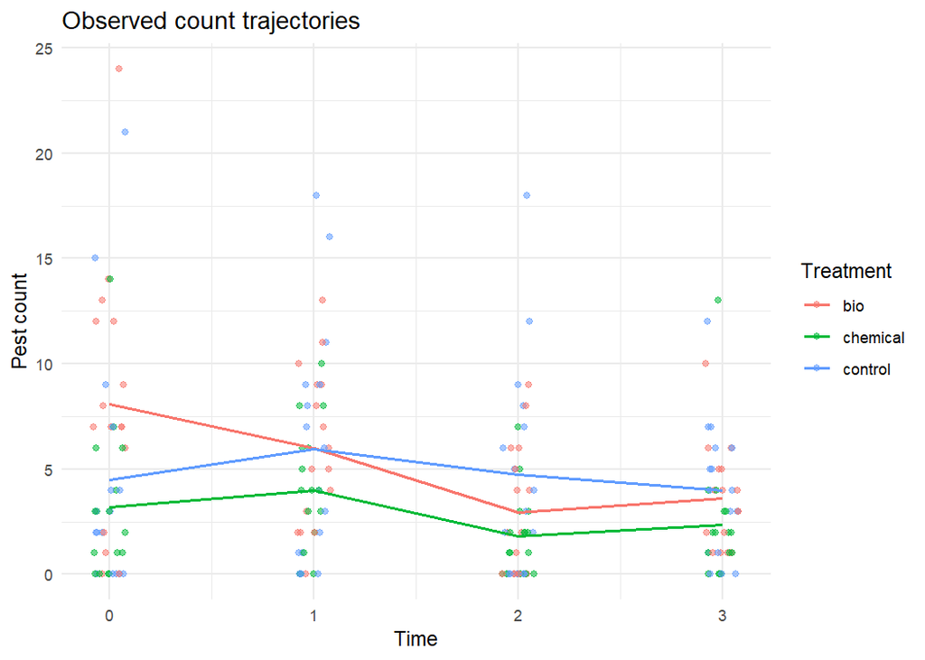

```r
if (requireNamespace("ggplot2", quietly = TRUE)) {
  ggplot2::ggplot(cnt, ggplot2::aes(time, count, colour = treatment)) +
    ggplot2::geom_jitter(width = 0.08, height = 0, alpha = 0.55) +
    ggplot2::stat_summary(fun = mean, geom = "line", ggplot2::aes(group = treatment), linewidth = 0.8) +
    ggplot2::labs(
      x = "Time",
      y = "Pest count",
      colour = "Treatment",
      title = "Observed count trajectories"
    ) +
    ggplot2::theme_minimal(base_size = 11)
}
```

**How to read the figure.** The plotted treatment means are descriptive. The mixed model additionally accounts for repeated plot structure, conditional distribution, and any modeled zero or dispersion process.

# 15 14. A practical model-building sequence for counts

A defensible sequence is:

1. specify the fixed and random structure from the design;
2. fit a Poisson baseline if scientifically reasonable;
3. inspect dispersion and residual diagnostics;
4. move to a negative-binomial family if overdispersion is material;
5. evaluate zero inflation only if diagnostics and biology support a second zero mechanism;
6. add residual temporal/spatial structure if dependence remains;
7. compare conclusions across reasonable candidates.

# 16 15. Reporting checklist for GLMMs

Report:

- response definition and denominator when relevant;
- distribution family;
- link function;
- random effects;
- zero-inflation formula, if fitted;
- dispersion formula, if fitted;
- diagnostics;
- effect scale used in interpretation;
- estimates with confidence intervals;
- multiplicity adjustment for multiple contrasts.

# 17 16. Practice exercises

## 17.1 Exercise 1: Poisson versus NB2

Fit both models and inspect `mixed_diagnose(..., simulate=TRUE)` if `DHARMa` is available. Does the more flexible family solve a visible residual problem?

## 17.2 Exercise 2: zero-inflation formula

Compare `ziformula = ~ 1` with `ziformula = ~ treatment`. Explain the scientific claim implied by allowing the structural-zero probability to vary among treatments.

```r
if (requireNamespace("glmmTMB", quietly = TRUE)) {
  zi_intercept <- mixed_zero_inflated(
    count ~ treatment * time + (1 | plot),
    data = cnt,
    family = glmmTMB::nbinom2,
    ziformula = ~ 1
  )
}
```

## 17.3 Exercise 3: beta link

Fit beta models with logit and probit links. Compare fitted conclusions on the response scale rather than coefficient magnitude alone.

```r
if (requireNamespace("glmmTMB", quietly = TRUE)) {
  beta_logit <- mixed_beta(severity ~ treatment + (1 | block), be, "logit")
  beta_probit <- mixed_beta(severity ~ treatment + (1 | block), be, "probit")
}
```

# 18 17. Key take-home messages

- Distribution choice starts from the response-generating process.
- Random effects account for grouping but do not automatically solve overdispersion or residual dependence.
- Negative-binomial and zero-inflated models answer different questions.
- Beta models require support strictly inside `(0,1)` unless a boundary-capable alternative is used.
- Simulation-based diagnostics are highly useful for GLMMs.
- A lower information criterion alone is not a scientific argument for complexity.

# 19 18. What comes next

The next stage begins with `05-residual-covariance.Rmd`, where we separate group-level random effects from residual temporal correlation and heteroscedasticity.

# 20 References

`lme4` provides a foundational implementation of linear and generalized linear mixed models (Bates et al. 2015). `glmmTMB` extends this framework with flexible families, zero-inflation, and related model components (Brooks et al. 2017).

Bates, Douglas, Martin Maechler, Ben Bolker, and Steve Walker. 2015. “Fitting Linear Mixed-Effects Models Using Lme4.” *Journal of Statistical Software* 67 (1): 1–48. https://doi.org/10.18637/jss.v067.i01.

Brooks, Mollie E., Kasper Kristensen, Koen J. van Benthem, et al. 2017. “glmmTMB Balances Speed and Flexibility Among Packages for Zero-Inflated Generalized Linear Mixed Modeling.” *The R Journal* 9 (2): 378–400. https://doi.org/10.32614/RJ-2017-066.